# Module 1 - Lesson 02

2017-08-31

## Outline

- Literate Programming - The `WEB` System
- Dynamic Documentation - `SWEAVE`
- The Next Generation - `knitr` + `rmarkdown`
- Universal Document Converter - `Pandoc`

## The `WEB` System by Donald Knuth

The first published literate programming environment was `WEB`. Donald Knuth introduced it back in 1981 combining his TeX typesetting system with the Pascal programming language.

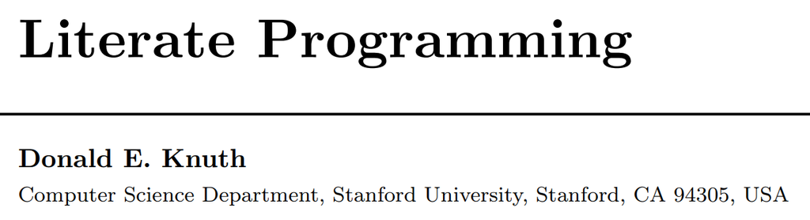

> *"I chose the name `WEB` partly because it was one of the few three-letter words of English that hadn’t already been applied to computers. But as time went on, I’ve become extremely pleased with the name, because I think that a complex piece of software is, indeed, best **regarded as a web that has been delicately pieced together from simple materials**. … If we **express a program as a web of ideas**, we can emphasize its structural properties in a natural and satisfying way."*http://www.literateprogramming.com/knuthweb.pdf

## Funnel Web Tutorial Manual by Ross N. Williams

There are various implementations of the literate programming concept, one of which is Funnel Web by Ross N. Williams

[figure not shown]

> *"A traditional computer program consists of a **text file containing program code**. Scattered in amongst the program code are comments which describe the various parts of the code.*

> *In literate programming the emphasis is reversed. Instead of writing code containing documentation, the literate programmer writes **documentation containing code**. … **The "program" then becomes primarily a document directed at humans**, with the code being herded between "code delimiters" from where it can be extracted and shuffled out sideways to the language system by literate programming tools."*http://www.literateprogramming.com/fwtut.pdf

## `SWEAVE` by Friedrich Leisch

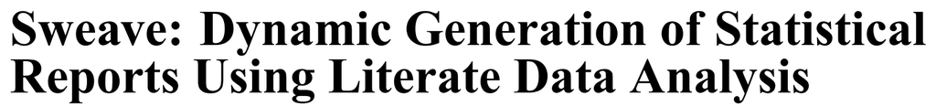

> What is Sweave?

> *"Sweave is a tool that allows to embed the R code for complete data analyses in latex documents. The purpose is to create dynamic reports, which can be updated automatically if data or analysis change. Instead of inserting a prefabricated graph or table into the report, the master document contains the R code necessary to obtain it. When run through R, all data analysis output (tables, graphs, etc.) is created on the fly and inserted into a final latex document. The report can be automatically updated if data or analysis change, which allows for truly reproducible research."*Friedrich Leisch. Sweave: Dynamic generation of statistical reports using literate data analysis. In Wolfgang Härdle and Bernd Rönz, editors, Compstat 2002 - Proceedings in Computational Statistics, pages 575-580. Physica Verlag, Heidelberg, 2002. ISBN 3-7908-1517-9.

## The next evolution `<- knitr`

[figure not shown]

In 2012 Yihui Xie, created and released the `knitr` package for R to extend the capabilities of `SWEAVE` beyond LaTeX.

> *"The **knitr** package was designed to be a transparent engine for dynamic report generation with R, solve some long-standing problems in Sweave, and combine features in other add-on packages into one package."*https://yihui.name/knitr/

## The next evolution `<- ... + rmarkdown`

[figure not shown]

- In 2014, RStudio released `rmarkdown` to extend the `markdown` language originally intended to write documents for the "web" *(i.e. HTML)*.https://daringfireball.net/projects/markdown/syntax
- `rmarkdown` leverages `Pandoc` *("universal document converter")* http://pandoc.org/index.html to convert between formats: from HTML (readable by web browsers) to DOC (such as from Microsoft Word or Google Docs) to ODT (Libre Office) to PDF (portable document format) to others like EPUB (e-books), HTML5 slide shows (slidy, ioslides), and TeX based documents and slides (Beamer).

## Pandoc https://pandoc.org/

…often called the *Swiss-Army knife* for converting files from one format to another. Pandoc can convert documents in markdown, reStructuredText, textile, HTML, DocBook, LaTeX, MediaWiki markup, TWiki markup, OPML, Emacs Org-Mode, Txt2Tags, Microsoft Word docx, LibreOffice ODT, EPUB, or Haddock markup to

- HTML formats: XHTML, HTML5,Slidy, reveal.js, Slideous, S5, DZSlides.
- Word processor formats: Microsoft Word docx, OpenOffice/LibreOffice ODT, OpenDocument XML
- Ebooks: EPUB version 2 or 3, FictionBook2
- Documentation formats: DocBook, TEI Simple, GNU TexInfo, Groff man pages, Haddock markup
- Page layout formats: InDesign ICML
- Outline formats: OPML
- TeX formats: LaTeX, ConTeXt, LaTeX Beamer slides
- PDF via LaTeX
- Lightweight markup formats: Markdown (including CommonMark), reStructuredText, AsciiDoc, MediaWiki markup, DokuWiki markup, Emacs Org-Mode, Textile
- Custom formats: written in lua.

## Next in Lesson 03 …

Reproducible Principles & Practices

plus

Examples of Reproducible Documents & Templates